# HW5

Kaela Finegan and Lucas Shin

12/3/2020

```r
library(png)
library(tidyverse)
library(stringr)
library(reshape)
```

```r
library(ptw)
library(ggplot2)
```

Step 1: Run an all vs. all matching experiment on face data that we collected over the past five weeks (see Homework 4). In an all vs. all experiment, the enrolled/gallery and the query/probe set are the same. Therefore, you should have a symmetric matrix.

All of Grant’s code for HW4 implementing LBP:

```r
padding <- function(src){
  mat1 <- padzeros(src,1,side="both")
  mat2 <- padzeros(t(mat1),1,side="both")
  return(t(mat2))
}

lbpthreshold <- function(mat){
  # Extracts the middle element of the 3 by 3 matrix
  val <- mat[2,2]
  tmp <- mat
  tmp[mat >= val] <- 1
  tmp[mat < val] <- 0
  dst <- c(tmp[1,1], tmp[1,2], tmp[1,3], tmp[2,3], tmp[3,3], tmp[3,2], tmp[3,1], tmp[2,1])
  # Removes the middle element of the  3x3 vector
  return(dst) }

lbpval <- function(x){ val <- 0
for (i in 1:length(x)){
  val <- val + x[i] * 2 ^ (i-1)
}
return(val) }

# Creates a new matrix full of zeros, smaller in size to remove the zero padding
lbpmat <- function(src){
  dst <- matrix(0L, nrow = (dim(src)[1] - 2), ncol = (dim(src)[2] - 2))

  rows <- dim(src)[1]
  cols <- dim(src)[2]
  for (row in c(2:(rows-1))){
    for(col in c(2:(cols-1))){
      tmp <- src[c( (row-1):(row+1)), c( (col-1):(col+1))]
      threshvec <- lbpthreshold(tmp)
      binnum <- lbpval(threshvec)
      dst[row-1,col-1] <- binnum
    }
  }
  return(dst)
}

lbphist <- function(src){
  bins <- seq(0,256,l=9)
  h <- hist(as.vector(src), breaks = bins,plot=FALSE)
  return(h$counts)
}

lbpfeatvec <- function(src, numywin, numxwin){
  rows <- dim(src)[1]
  cols <- dim(src)[2]
  feats = c()
  yrange <- floor(rows / numywin) - 1
  xrange <- floor(cols / numxwin) - 1
  for(y in c(1:numywin)){
    for(x in c(1:numxwin)){
      ymin <- y + (y-1)*yrange
      ymax <- y + (y-1)*yrange + yrange
      xmin <- x + (x-1)*xrange
      xmax <- x + (x-1)*xrange + xrange
      tmp <- src[c(ymin:ymax),c(xmin:xmax)]
      featvec <- lbphist(tmp)
      feats <- c(feats, featvec)
    }
  }
  return(feats) }

lbpmatcher <- function(l1, l2){
  return (sum(abs(l1 - l2)))
}

imgdir <- "/Users/lucasshin/Desktop/Biometrics/Biometrics HW 5/fa20cropped/"
img_filenames <- list.files(path=imgdir, pattern="*.png")
# Stores all of the LBP feature vectors to compare two images
lbpimg <- vector("list", length(img_filenames))
lbpvecs <- vector("list", length(img_filenames))
# Creates 16 windows from image
nrows <- 4
ncols <- 4
for (i in 1:length(img_filenames)) {
  imgdata <- readPNG(paste(imgdir, img_filenames[i], sep =""))
  imgdata <- (imgdata - min(imgdata)) / (max(imgdata) - min(imgdata))
  paddedimg <- padding(imgdata)
  lbpimg[[i]] <- lbpmat(paddedimg)
  lbpvecs[[i]] <- lbpfeatvec(lbpimg[[i]], nrows, ncols)
}

#Create a matrix to hold scores
scores = matrix(0L, nrow = length(img_filenames), ncol = length(img_filenames))
for (i in 1:length(img_filenames)) {
for (j in 1:length(img_filenames)) {
scores[i,j] <- lbpmatcher(lbpvecs[[i]], lbpvecs[[j]])
} }
```

Step 1 for PCA:

```r
# Directory of Training Data
trainingdir <- "/Users/lucasshin/Desktop/Biometrics/Biometrics HW 5/testingfaces2/"
training_filenames <- list.files(path=trainingdir, pattern="*.png")
trainingdata <- vector("list", length(training_filenames))
for (i in 1:length(training_filenames)) {
trainingdata[[i]] <- readPNG(paste(trainingdir, training_filenames[i], sep =""))
trainingdata[[i]] <- (trainingdata[[i]] - min(trainingdata[[i]])) / (max(trainingdata[[i]]) -
                                                                       min(trainingdata[[i]]))
}

trainingmatrix = c()
for (i in 1:length(training_filenames)){
  trainingmatrix = cbind(trainingmatrix, as.vector(t(trainingdata[[i]])))
}
u = rowMeans(trainingmatrix)

normmatrix <- apply(trainingmatrix, 2, function(x) x - u)

covarmtx = normmatrix %*% t(normmatrix)

ev = eigen(covarmtx)
pc = ev$vectors[,c(1:15)]


testingdir <- "/Users/lucasshin/Desktop/Biometrics/Biometrics HW 5/fa20cropped/"
testing_filenames <- list.files(path=testingdir, pattern="*.png")
testingdata <- vector("list", length(testing_filenames))
for (i in 1:length(testing_filenames)) {
testingdata[[i]] <- readPNG(paste(testingdir, testing_filenames[i], sep =""))
}
testingmatrix = c()
for (i in 1:length(testing_filenames)){
  testingmatrix = cbind(testingmatrix, as.vector(t(testingdata[[i]])))
}


weights <- vector("list", 0)
for(img in 1:length(testing_filenames)){
  img_data <- testingmatrix[ , img]
  weight <- t(pc) %*% img_data
  weight2 <- abs(weight)
  #weights <- c(weights, weight2)
  weights[[img]] <- weight2
}

#Create a matrix to hold scores
scores1 = matrix(0L, nrow = length(testing_filenames), ncol = length(testing_filenames))
for (i in 1:length(testing_filenames)) {
  for (j in 1:length(testing_filenames)) {
    scores1[i,j] <- lbpmatcher(weights[[i]], weights[[j]])
} }
```

Step 2: Plot the distribution of genuine and impostor scores for the LBP and PCA face matching algorithms (see Homework 1).

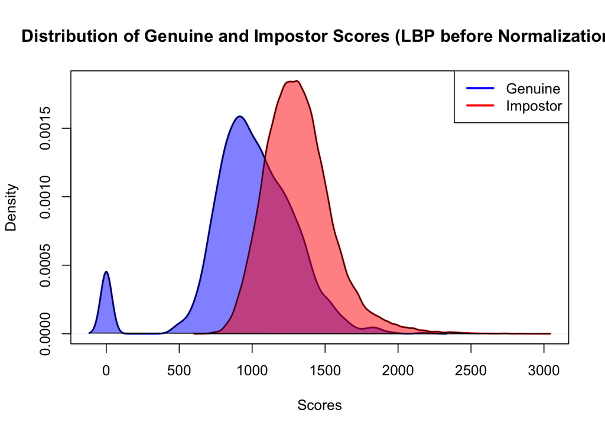

```r
d <- scores
gallery <- c()
query <- c()

for (i in 1:length(img_filenames)) {
   gallery <- c(gallery, substr(img_filenames[i], start = 2, stop = 4))
}

gallery <- as.matrix(gallery)
query <- gallery

colnames(d) <- as.matrix(gallery)
rownames(d) <- as.matrix(query)
m <- melt(d)
names(m) <- c("xA", "xE", "dist")

genuine <- m[m[,1] == m[,2],]
impostor <- m[m[,1] != m[,2],]

genden <- density(genuine[,3])
impden <- density(impostor[,3])

xmin <- min(genden$x,impden$x)
xmax <- max(genden$x,impden$x)
ymin <- min(genden$y,impden$y)
ymax <- max(genden$y,impden$y)

plot(genden, xlim=c(xmin,xmax), ylim=c(ymin,ymax), main="Distribution of Genuine and Impostor Scores (LBP before Normalization)",
     xlab="Scores", ylab="Density", col = "blue", lwd = 2)
lines(impden, col = "red", lwd = 2)
polygon(genden, col=rgb(0,0,1,0.5))
polygon(impden, col=rgb(1,0,0,0.5))
legend('topright', c("Genuine","Impostor"), col = c("blue","red"), lty = c(1,1), lwd = c(2.5,2.5))
```

```r
dprime = function(mu1,mu0,sig1,sig0) { sqrt(2) * abs(mu1 - mu0) / sqrt(sig1^2 + sig0^2) }
mu1 = mean(genuine[,3])
mu0 = mean(impostor[,3])
sig1 = sd(genuine[,3])
sig0 = sd(impostor[,3])
#print(paste("Sensitivity Index:",dprime(mu1,mu0,sig1,sig0)))

# Distance scores are used to compute this DET curve. If the scores are # similarity scores, then reverse the logical operators
DET = function(threshold, gen, imp){
    # The percentage of impostor scores that are claimed to be genuine
  far = length(imp[ imp < threshold]) / length(imp)
  # The percentage of true identities that are claimed to be impostors
  frr = length(gen[ gen > threshold]) / length(gen)
  datapoint = c(threshold,far,frr)
  return(datapoint)
}

thresholds = seq(xmin, xmax,(xmax-xmin)/100)
detcurve = t(sapply(thresholds, DET, genuine[,3], impostor[,3]))
colnames(detcurve) = c("threshold","far","frr")
#plot(detcurve[,2], detcurve[,3], type = "l", lwd = 2, xlab = "FAR", ylab = "FRR", main="Detection Error Tradeoff #Curve (LBP before Normalization)")
#y = seq(0,1)
#x = seq(0,1)
#lines(x,y , lty = 2, col = "gray40")
#legend('topright', c("ROC","ERR"), col = c("black","gray40"), lty = c(1,2), lwd = c(2.5,2.5))
```

Step 2 for PCA:

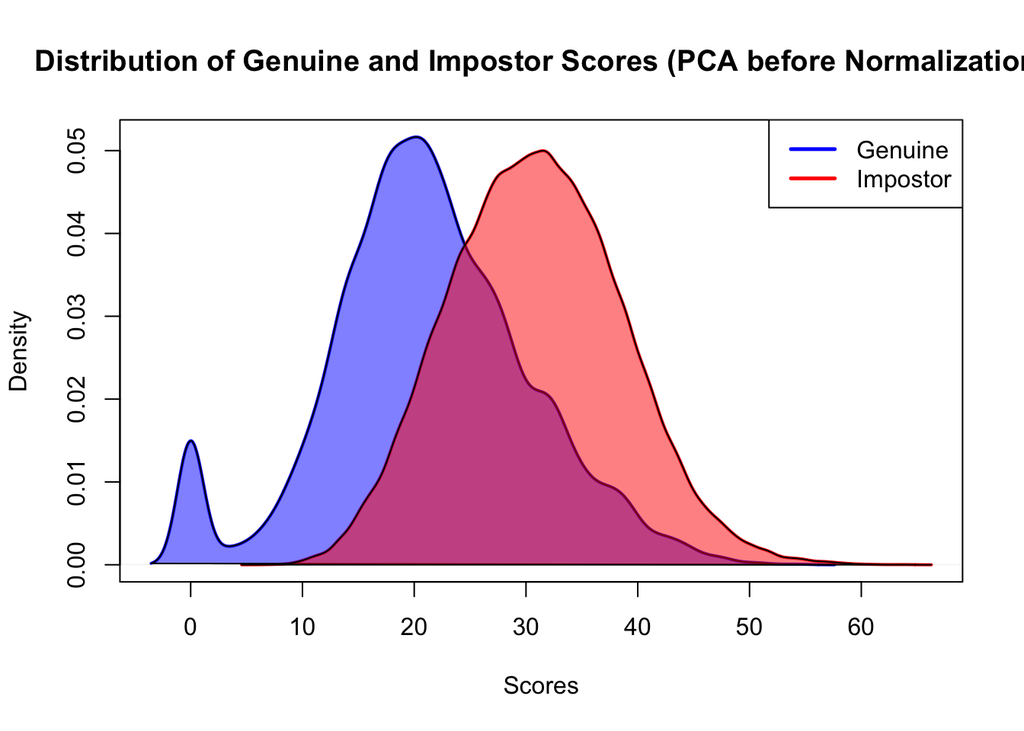

```r
d <- scores1

names <- c()
for(image in 1:length(testing_filenames)){
  id <- str_sub(testing_filenames[image], 2, 4)
  names <- c(names, id)
}

query <- as.matrix(names)
gallery <-  as.matrix(names)
colnames(d) <- gallery
rownames(d) <- query

m <- melt(d)
names(m) <- c("xA", "xE", "dist")

genuine <- m[m[,1] == m[,2],]
impostor <- m[m[,1] != m[,2],]

genden <- density(genuine[,3])
impden <- density(impostor[,3])

xmin <- min(genden$x,impden$x)
xmax <- max(genden$x,impden$x)
ymin <- min(genden$y,impden$y)
ymax <- max(genden$y,impden$y)


plot(genden, xlim=c(xmin,xmax), ylim=c(ymin,ymax), main="Distribution of Genuine and Impostor Scores (PCA before Normalization)",
     xlab="Scores", ylab="Density", col = "blue", lwd = 2)
lines(impden, col = "red", lwd = 2)
polygon(genden, col=rgb(0,0,1,0.5))
polygon(impden, col=rgb(1,0,0,0.5))
legend('topright', c("Genuine","Impostor"), col = c("blue","red"), lty = c(1,1), lwd = c(2.5,2.5))
```

```r
dprime = function(mu1,mu0,sig1,sig0) { sqrt(2) * abs(mu1 - mu0) / sqrt(sig1^2 + sig0^2) }
mu1 = mean(genuine[,3])
mu0 = mean(impostor[,3])
sig1 = sd(genuine[,3])
sig0 = sd(impostor[,3])
#print(paste("Sensitivity Index:",dprime(mu1,mu0,sig1,sig0)))

# Distance scores are used to compute this DET curve. If the scores are # similarity scores, then reverse the logical operators
DET = function(threshold, gen, imp){
    # The percentage of impostor scores that are claimed to be genuine
  far = length(imp[ imp < threshold]) / length(imp)
  # The percentage of true identities that are claimed to be impostors
  frr = length(gen[ gen > threshold]) / length(gen)
  datapoint = c(threshold,far,frr)
  return(datapoint)
}

thresholds = seq(xmin, xmax,(xmax-xmin)/100)
detcurve = t(sapply(thresholds, DET, genuine[,3], impostor[,3]))
colnames(detcurve) = c("threshold","far","frr")
# plot(detcurve[,2], detcurve[,3], type = "l", lwd = 2, xlab = "FAR", ylab = "FRR", main="Detection Error #Tradeoff Curve (PCA before Normalization)")
# y = seq(0,1)
# x = seq(0,1)
# lines(x,y , lty = 2, col = "gray40")
# legend('topright', c("ROC","ERR"), col = c("black","gray40"), lty = c(1,2), lwd = c(2.5,2.5))
```

Step 3: Score Normalization

```r
scores_lbp <- scores
scores_pca <- scores1

max_lbp <- max(scores_lbp)
max_pca <- max(scores_pca)
min_lbp <- min(scores_lbp)
min_pca <- min(scores_pca)
range_lbp <- max_lbp - min_lbp
range_pca <- max_pca - min_pca


for (i in 1:length(img_filenames)) {
  for (j in 1:length(img_filenames)) {
    scores_lbp[i,j] <- (scores_lbp[i,j] - min_lbp) / range_lbp
  } }

for (i in 1:length(testing_filenames)) {
  for (j in 1:length(testing_filenames)) {
    scores_pca[i,j] <- (scores_pca[i,j] - min_pca) / range_pca
} }
```

Step 4: Score Fusion

```r
#Create a matrix to hold scores

scores_max = matrix(0L, nrow = length(testing_filenames), ncol = length(testing_filenames))
for (i in 1:length(testing_filenames)) {
  for (j in 1:length(testing_filenames)) {
    scores_max[i,j] <- max(scores_pca[i,j], scores_lbp[i,j])
  } }

scores_min = matrix(0L, nrow = length(testing_filenames), ncol = length(testing_filenames))
for (i in 1:length(testing_filenames)) {
  for (j in 1:length(testing_filenames)) {
    scores_min[i,j] <- min(scores_pca[i,j], scores_lbp[i,j])
  } }

scores_sum = matrix(0L, nrow = length(testing_filenames), ncol = length(testing_filenames))
for (i in 1:length(testing_filenames)) {
  for (j in 1:length(testing_filenames)) {
    scores_sum[i,j] <- scores_pca[i,j] + scores_lbp[i,j]
  } }
```

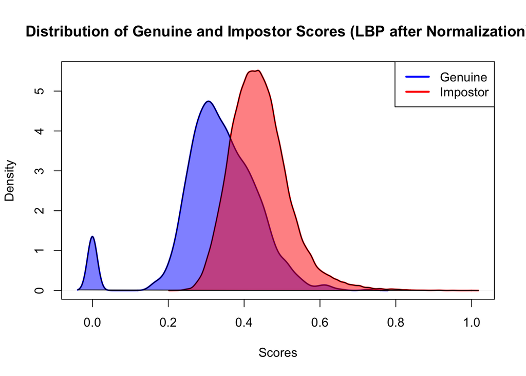

```r
# for scores
d <- scores_lbp

names <- c()
for(image in 1:length(img_filenames)){
  id <- str_sub(img_filenames[image], 2, 4)
  names <- c(names, id)
}

query <- as.matrix(names)
gallery <-  as.matrix(names)
colnames(d) <- gallery
rownames(d) <- query

m <- melt(d)
names(m) <- c("xA", "xE", "dist")

genuine <- m[m[,1] == m[,2],]
impostor <- m[m[,1] != m[,2],]

genden <- density(genuine[,3])
impden <- density(impostor[,3])

xmin <- min(genden$x,impden$x)
xmax <- max(genden$x,impden$x)
ymin <- min(genden$y,impden$y)
ymax <- max(genden$y,impden$y)

plot(genden, xlim=c(xmin,xmax), ylim=c(ymin,ymax), main="Distribution of Genuine and Impostor Scores (LBP after Normalization)",
     xlab="Scores", ylab="Density", col = "blue", lwd = 2)
lines(impden, col = "red", lwd = 2)
polygon(genden, col=rgb(0,0,1,0.5))
polygon(impden, col=rgb(1,0,0,0.5))
legend('topright', c("Genuine","Impostor"), col = c("blue","red"), lty = c(1,1), lwd = c(2.5,2.5))
```

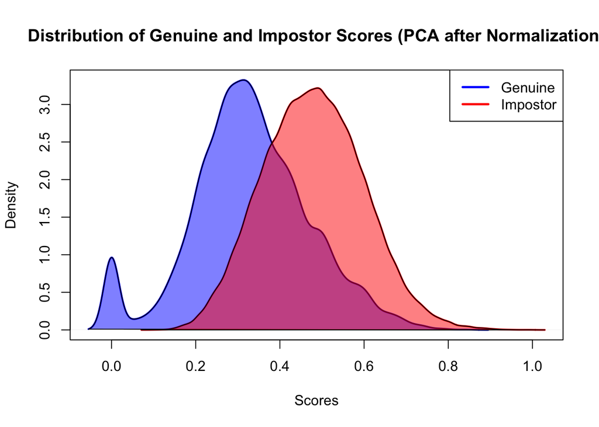

```r
dprime = function(mu1,mu0,sig1,sig0) { sqrt(2) * abs(mu1 - mu0) / sqrt(sig1^2 + sig0^2) }
mu1 = mean(genuine[,3])
mu0 = mean(impostor[,3])
sig1 = sd(genuine[,3])
sig0 = sd(impostor[,3])
#print(paste("Sensitivity Index:",dprime(mu1,mu0,sig1,sig0)))

# Distance scores are used to compute this DET curve. If the scores are # similarity scores, then reverse the logical operators
DET = function(threshold, gen, imp){
    # The percentage of impostor scores that are claimed to be genuine
  far = length(imp[ imp < threshold]) / length(imp)
  # The percentage of true identities that are claimed to be impostors
  frr = length(gen[ gen > threshold]) / length(gen)
  datapoint = c(threshold,far,frr)
  return(datapoint)
}

thresholds = seq(xmin, xmax,(xmax-xmin)/100)
detcurve1 = t(sapply(thresholds, DET, genuine[,3], impostor[,3]))
colnames(detcurve1) = c("threshold","far","frr")

# for scores1
d <- scores_pca

names <- c()
for(image in 1:length(img_filenames)){
  id <- str_sub(img_filenames[image], 2, 4)
  names <- c(names, id)
}

query <- as.matrix(names)
gallery <-  as.matrix(names)
colnames(d) <- gallery
rownames(d) <- query

m <- melt(d)
names(m) <- c("xA", "xE", "dist")

genuine <- m[m[,1] == m[,2],]
impostor <- m[m[,1] != m[,2],]

genden <- density(genuine[,3])
impden <- density(impostor[,3])

xmin <- min(genden$x,impden$x)
xmax <- max(genden$x,impden$x)
ymin <- min(genden$y,impden$y)
ymax <- max(genden$y,impden$y)

plot(genden, xlim=c(xmin,xmax), ylim=c(ymin,ymax), main="Distribution of Genuine and Impostor Scores (PCA after Normalization)",
     xlab="Scores", ylab="Density", col = "blue", lwd = 2)
lines(impden, col = "red", lwd = 2)
polygon(genden, col=rgb(0,0,1,0.5))
polygon(impden, col=rgb(1,0,0,0.5))
legend('topright', c("Genuine","Impostor"), col = c("blue","red"), lty = c(1,1), lwd = c(2.5,2.5))
```

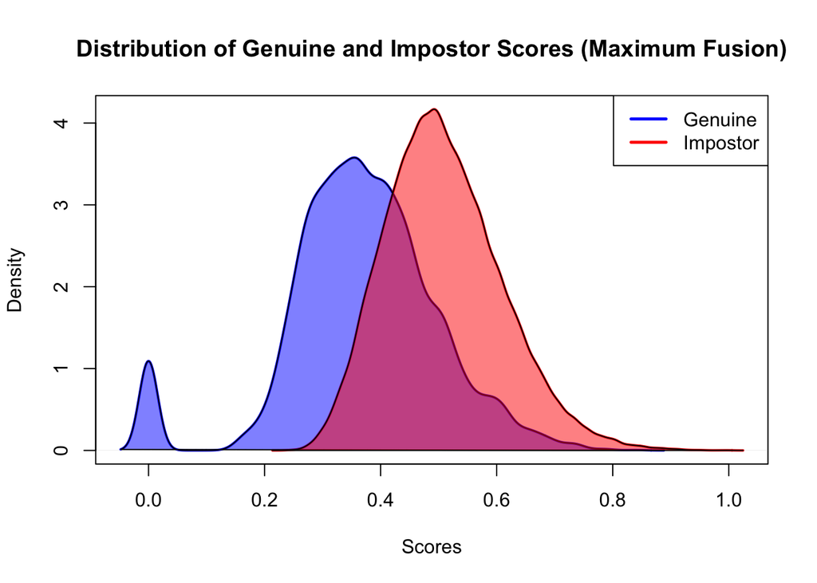

```r
dprime = function(mu1,mu0,sig1,sig0) { sqrt(2) * abs(mu1 - mu0) / sqrt(sig1^2 + sig0^2) }
mu1 = mean(genuine[,3])
mu0 = mean(impostor[,3])
sig1 = sd(genuine[,3])
sig0 = sd(impostor[,3])
#print(paste("Sensitivity Index:",dprime(mu1,mu0,sig1,sig0)))

# Distance scores are used to compute this DET curve. If the scores are # similarity scores, then reverse the logical operators
DET = function(threshold, gen, imp){
    # The percentage of impostor scores that are claimed to be genuine
  far = length(imp[ imp < threshold]) / length(imp)
  # The percentage of true identities that are claimed to be impostors
  frr = length(gen[ gen > threshold]) / length(gen)
  datapoint = c(threshold,far,frr)
  return(datapoint)
}

thresholds = seq(xmin, xmax,(xmax-xmin)/100)
detcurve2 = t(sapply(thresholds, DET, genuine[,3], impostor[,3]))
colnames(detcurve2) = c("threshold","far","frr")


# scores_max
d <- scores_max

names <- c()
for(image in 1:length(img_filenames)){
  id <- str_sub(img_filenames[image], 2, 4)
  names <- c(names, id)
}

query <- as.matrix(names)
gallery <-  as.matrix(names)
colnames(d) <- gallery
rownames(d) <- query

m <- melt(d)
names(m) <- c("xA", "xE", "dist")

genuine <- m[m[,1] == m[,2],]
impostor <- m[m[,1] != m[,2],]

genden <- density(genuine[,3])
impden <- density(impostor[,3])

xmin <- min(genden$x,impden$x)
xmax <- max(genden$x,impden$x)
ymin <- min(genden$y,impden$y)
ymax <- max(genden$y,impden$y)

plot(genden, xlim=c(xmin,xmax), ylim=c(ymin,ymax), main="Distribution of Genuine and Impostor Scores (Maximum Fusion)",
     xlab="Scores", ylab="Density", col = "blue", lwd = 2)
lines(impden, col = "red", lwd = 2)
polygon(genden, col=rgb(0,0,1,0.5))
polygon(impden, col=rgb(1,0,0,0.5))
legend('topright', c("Genuine","Impostor"), col = c("blue","red"), lty = c(1,1), lwd = c(2.5,2.5))
```

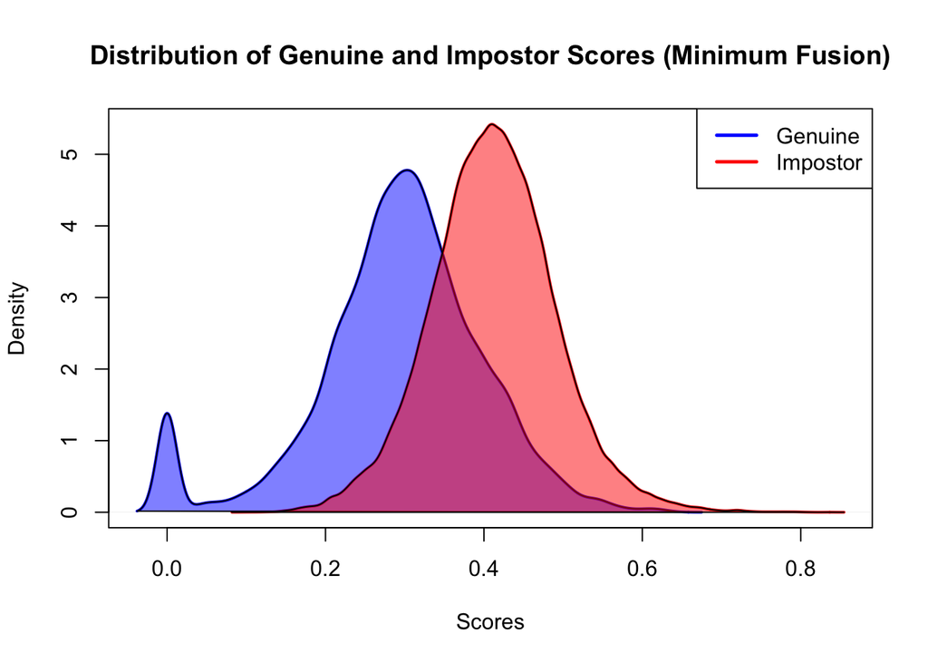

```r
dprime = function(mu1,mu0,sig1,sig0) { sqrt(2) * abs(mu1 - mu0) / sqrt(sig1^2 + sig0^2) }
mu1 = mean(genuine[,3])
mu0 = mean(impostor[,3])
sig1 = sd(genuine[,3])
sig0 = sd(impostor[,3])
#print(paste("Sensitivity Index:",dprime(mu1,mu0,sig1,sig0)))

# Distance scores are used to compute this DET curve. If the scores are # similarity scores, then reverse the logical operators
DET = function(threshold, gen, imp){
    # The percentage of impostor scores that are claimed to be genuine
  far = length(imp[ imp < threshold]) / length(imp)
  # The percentage of true identities that are claimed to be impostors
  frr = length(gen[ gen > threshold]) / length(gen)
  datapoint = c(threshold,far,frr)
  return(datapoint)
}

thresholds = seq(xmin, xmax,(xmax-xmin)/100)
detcurve3 = t(sapply(thresholds, DET, genuine[,3], impostor[,3]))
colnames(detcurve3) = c("threshold","far","frr")

# for scores_min
d <- scores_min

names <- c()
for(image in 1:length(img_filenames)){
  id <- str_sub(img_filenames[image], 2, 4)
  names <- c(names, id)
}

query <- as.matrix(names)
gallery <-  as.matrix(names)
colnames(d) <- gallery
rownames(d) <- query

m <- melt(d)
names(m) <- c("xA", "xE", "dist")

genuine <- m[m[,1] == m[,2],]
impostor <- m[m[,1] != m[,2],]

genden <- density(genuine[,3])
impden <- density(impostor[,3])

xmin <- min(genden$x,impden$x)
xmax <- max(genden$x,impden$x)
ymin <- min(genden$y,impden$y)
ymax <- max(genden$y,impden$y)

plot(genden, xlim=c(xmin,xmax), ylim=c(ymin,ymax), main="Distribution of Genuine and Impostor Scores (Minimum Fusion)",
     xlab="Scores", ylab="Density", col = "blue", lwd = 2)
lines(impden, col = "red", lwd = 2)
polygon(genden, col=rgb(0,0,1,0.5))
polygon(impden, col=rgb(1,0,0,0.5))
legend('topright', c("Genuine","Impostor"), col = c("blue","red"), lty = c(1,1), lwd = c(2.5,2.5))
```

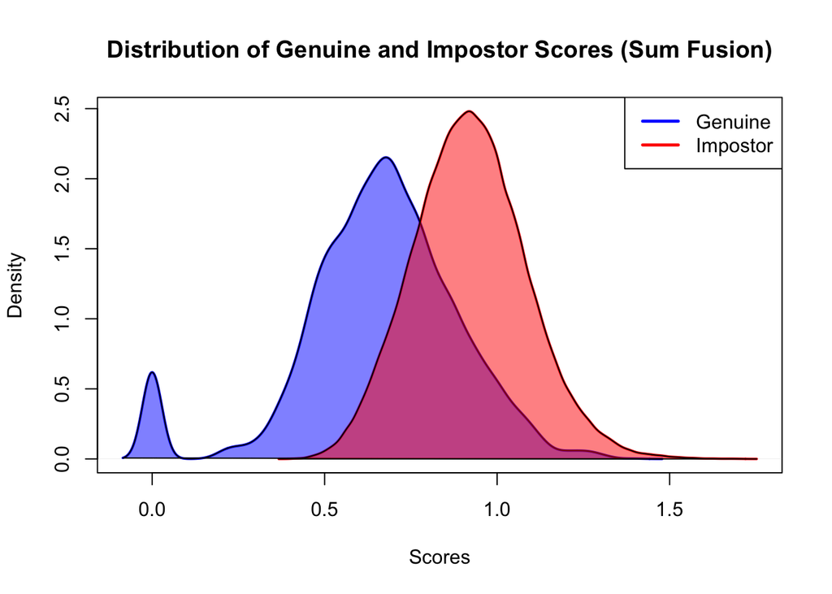

```r
dprime = function(mu1,mu0,sig1,sig0) { sqrt(2) * abs(mu1 - mu0) / sqrt(sig1^2 + sig0^2) }
mu1 = mean(genuine[,3])
mu0 = mean(impostor[,3])
sig1 = sd(genuine[,3])
sig0 = sd(impostor[,3])
#print(paste("Sensitivity Index:",dprime(mu1,mu0,sig1,sig0)))

# Distance scores are used to compute this DET curve. If the scores are # similarity scores, then reverse the logical operators
DET = function(threshold, gen, imp){
    # The percentage of impostor scores that are claimed to be genuine
  far = length(imp[ imp < threshold]) / length(imp)
  # The percentage of true identities that are claimed to be impostors
  frr = length(gen[ gen > threshold]) / length(gen)
  datapoint = c(threshold,far,frr)
  return(datapoint)
}

thresholds = seq(xmin, xmax,(xmax-xmin)/100)
detcurve4 = t(sapply(thresholds, DET, genuine[,3], impostor[,3]))
colnames(detcurve4) = c("threshold","far","frr")


# for scores_sum
d <- scores_sum

names <- c()
for(image in 1:length(img_filenames)){
  id <- str_sub(img_filenames[image], 2, 4)
  names <- c(names, id)
}

query <- as.matrix(names)
gallery <-  as.matrix(names)
colnames(d) <- gallery
rownames(d) <- query

m <- melt(d)
names(m) <- c("xA", "xE", "dist")

genuine <- m[m[,1] == m[,2],]
impostor <- m[m[,1] != m[,2],]

genden <- density(genuine[,3])
impden <- density(impostor[,3])

xmin <- min(genden$x,impden$x)
xmax <- max(genden$x,impden$x)
ymin <- min(genden$y,impden$y)
ymax <- max(genden$y,impden$y)

plot(genden, xlim=c(xmin,xmax), ylim=c(ymin,ymax), main="Distribution of Genuine and Impostor Scores (Sum Fusion)",
     xlab="Scores", ylab="Density", col = "blue", lwd = 2)
lines(impden, col = "red", lwd = 2)
polygon(genden, col=rgb(0,0,1,0.5))
polygon(impden, col=rgb(1,0,0,0.5))
legend('topright', c("Genuine","Impostor"), col = c("blue","red"), lty = c(1,1), lwd = c(2.5,2.5))
```